# Plots That Tell the Truth

R basics for the AI era · Session 3

DTR

2026-10-26

# Welcome

## Today’s route

- **Why plot?**
- **The grammar of graphs**
- **Choosing the type of plot**: geom
- **Scales, labels, themes**
- **Audit**: plots can mislead without a bug
- **Diagnostics and telling stories**

Same pairs as before. Three short audits with your neighbor.

## Where we left off

We’ve learned how to work with tables: filtered, grouped, summarized, joined, reshaped.

Today we make those tables **visible**.

AI can write beautiful plotting code, quickly. It does not check if the plot is **honest**. That’s your job.

## Same numbers, four datasets

```r
anscombe_long |>
  summarize(mean_x = mean(x), mean_y = mean(y), sd_y = sd(y),
            cor = cor(x, y), .by = set)
```

```
#> # A tibble: 4 x 5
#>   set   mean_x mean_y  sd_y   cor
#>   <chr>  <dbl>  <dbl> <dbl> <dbl>
#> 1 1          9   7.50  2.03 0.816
#> 2 2          9   7.50  2.03 0.816
#> 3 3          9   7.5   2.03 0.816
#> 4 4          9   7.50  2.03 0.817
```

Four sets with nearly identical summaries. Are they the same?

## Plot them

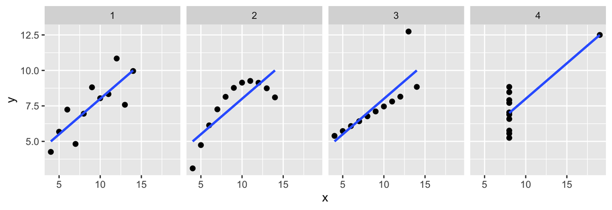

```r
ggplot(anscombe_long, aes(x, y)) +
  geom_point(size = 2.5) +
  geom_smooth(method = "lm", se = FALSE) +
  facet_wrap(~ set, nrow = 1)
```

**Bug:** summaries can hide the shape. Plot first.

# The grammar

## A plot is a recipe

- **Data**: a table
- **Aesthetics**: which columns go to x, y, color, size
- **Geom**: the shape that is drawn (points, bars, lines)
- Later: scales, facets, labels, themes

Layers are joined with `+`.

## Start with the canvas

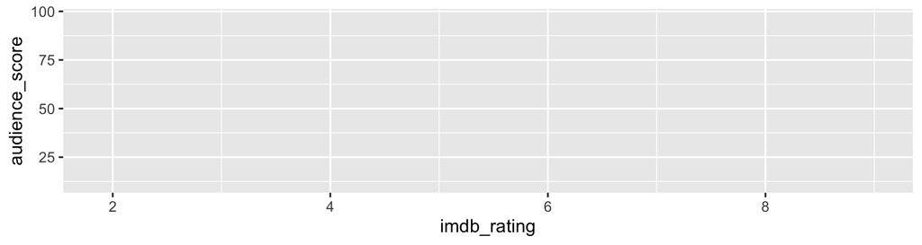

```r
ggplot(movies, aes(x = imdb_rating, y = audience_score))
```

Data and aesthetics only. The axes exist. Nothing is drawn yet.

## Add a geom

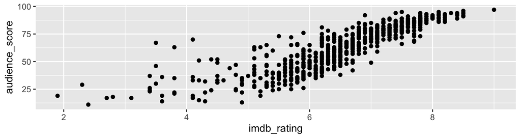

```r
ggplot(movies, aes(x = imdb_rating, y = audience_score)) +
  geom_point()
```

## Add another layer

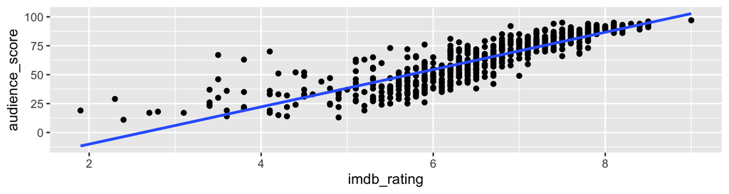

```r
ggplot(movies, aes(x = imdb_rating, y = audience_score)) +
  geom_point() +
  geom_smooth(method = "lm", se = FALSE)
```

Both layers **inherit** `x` and `y` from the first line.

## Map a column to color

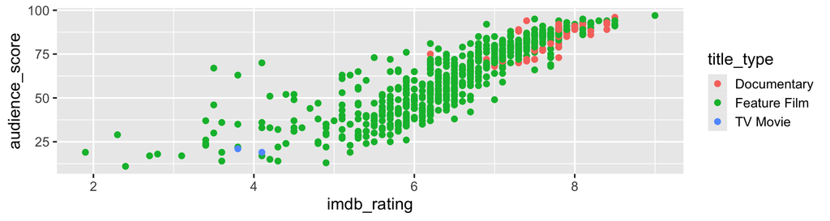

```r
ggplot(movies, aes(x = imdb_rating, y = audience_score)) +
  geom_point(aes(color = title_type))
```

Inside `aes()`: the color **depends on the data**, and a legend appears.

## Set a fixed look

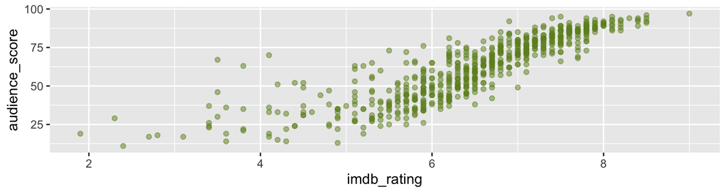

```r
ggplot(movies, aes(x = imdb_rating, y = audience_score)) +
  geom_point(color = "#6d8d24", size = 2, alpha = 0.5)
```

Outside `aes()`: one fixed value for **every** point. No legend.

## Task 1: code it

An AI was asked: “Make the points blue.” It wrote:

```r
ggplot(movies, aes(x = imdb_rating, y = audience_score)) +
  geom_point(aes(color = "blue"))
```

**Code it (4 min).** Run it. Are the points blue? Fix it, then add a straight trend line (no band) and axis labels with units.

## The answer

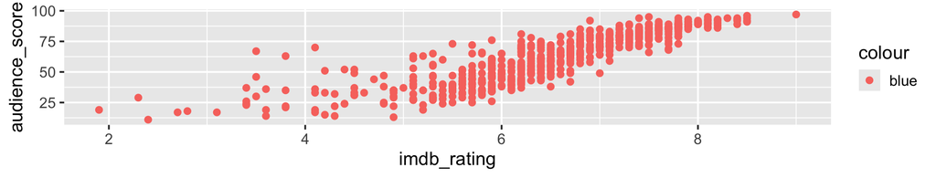

```r
ggplot(movies, aes(x = imdb_rating, y = audience_score)) +
  geom_point(aes(color = "blue"))
```

**Bug:** inside `aes()`, `"blue"` is a label. Fix: `geom_point(color = "blue")`.

## One way to finish it

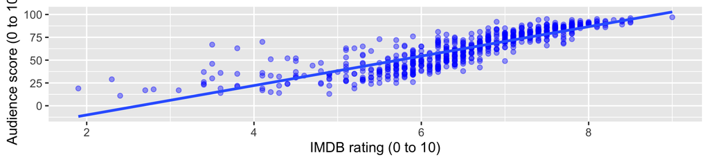

```r
ggplot(movies, aes(x = imdb_rating, y = audience_score)) +
  geom_point(color = "blue", alpha = 0.4) +
  geom_smooth(method = "lm", se = FALSE) +
  labs(x = "IMDB rating (0 to 10)", y = "Audience score (0 to 100)")
```

# Choose the geom

## Start from the question

| Question | Geom |
| --- | --- |
| One number: its **distribution** | `geom_histogram` |
| A number across **groups** | `geom_boxplot` |
| **Counts** per category | `geom_bar` |
| **Two numbers** | `geom_point` |
| A number over **time** | `geom_line` |

## Distribution of one number

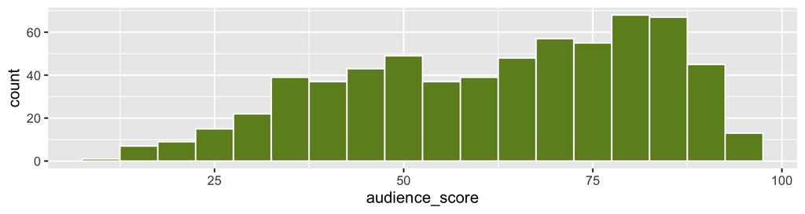

```r
ggplot(movies, aes(x = audience_score)) +
  geom_histogram(binwidth = 5, fill = "#6d8d24", color = "white")
```

Each bar counts the movies in a 5-point bin.

## Compare two distributions

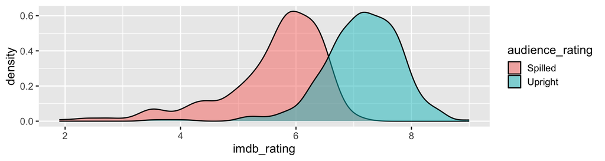

```r
ggplot(movies, aes(x = imdb_rating, fill = audience_rating)) +
  geom_density(alpha = 0.5)
```

`alpha` makes fills see-through so overlaps stay visible.

## Compare groups with boxplots

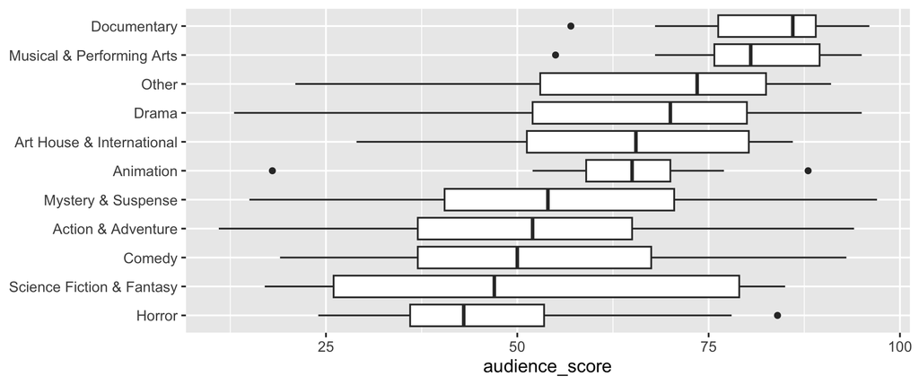

```r
ggplot(movies, aes(audience_score, fct_reorder(genre, audience_score))) +
  geom_boxplot() +
  labs(y = NULL)
```

## Count categories

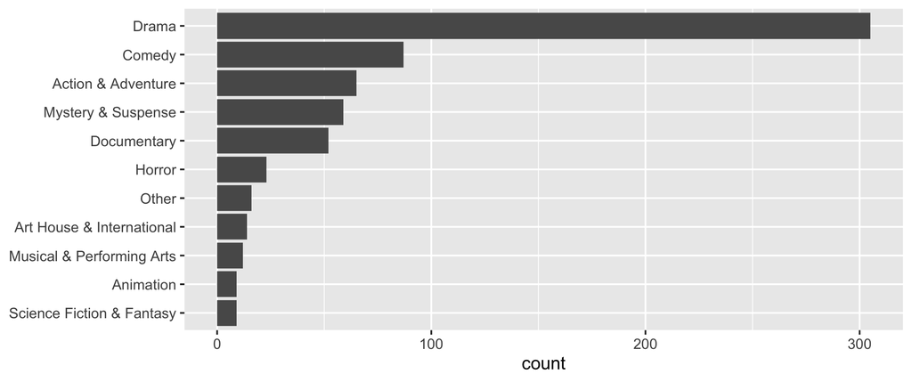

```r
ggplot(movies, aes(y = fct_rev(fct_infreq(genre)))) +
  geom_bar() +
  labs(y = NULL)
```

## geom_bar vs geom_col

You already have the counts? Use `geom_col()`. An AI often mixes them up:

```r
genre_counts <- movies |> count(genre)
ggplot(genre_counts, aes(y = genre, x = n)) +
  geom_bar()
```

```
#> Error in `geom_bar()`:
#> ! Problem while computing stat.
#> i Error occurred in the 1st layer.
#> Caused by error in `setup_params()`:
#> ! `stat_count()` must only have an x or y aesthetic.
```

`geom_bar` counts rows itself, so it refuses a count column. Use `geom_col()`.

## Two numbers: overplotting

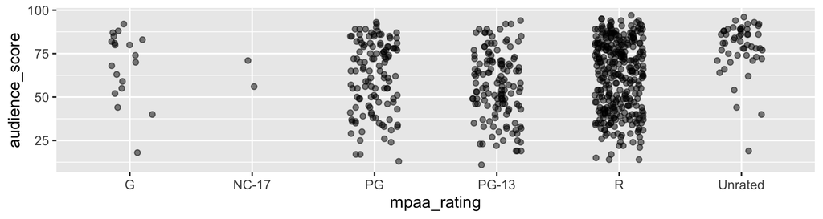

```r
ggplot(movies, aes(x = mpaa_rating, y = audience_score)) +
  geom_jitter(width = 0.2, height = 0, alpha = 0.5)
```

Without `geom_jitter`, points at the same x would stack into lines. `alpha` shows density.

## Change over time

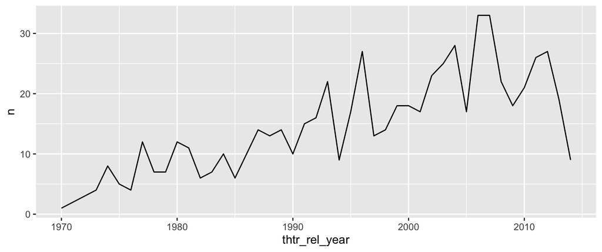

```r
movies |>
  count(thtr_rel_year) |>
  ggplot(aes(x = thtr_rel_year, y = n)) +
  geom_line()
```

Summarize first, then plot.

## Facets: small multiples

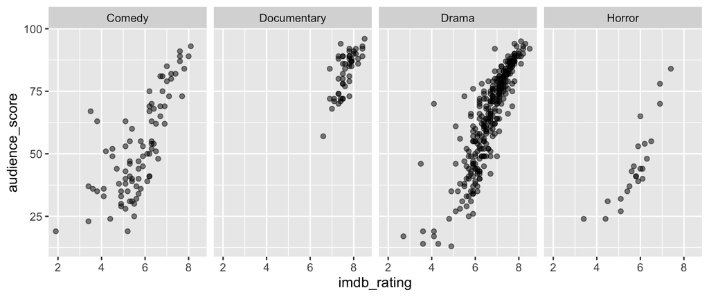

```r
movies |>
  filter(genre %in% c("Drama", "Comedy", "Documentary", "Horror")) |>
  ggplot(aes(x = imdb_rating, y = audience_score)) +
  geom_point(alpha = 0.5) +
  facet_wrap(~ genre, nrow = 1)
```

## Fractions with position = fill (FLEX)

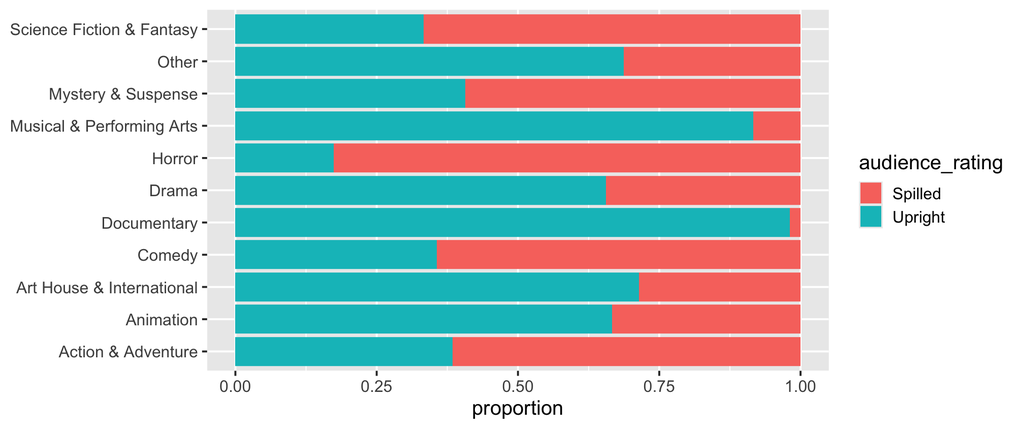

```r
ggplot(movies, aes(y = genre, fill = audience_rating)) +
  geom_bar(position = "fill") +
  labs(x = "proportion", y = NULL)
```

# Scales, labels, themes

## Store a plot, add layers

```r
p <- ggplot(movies, aes(x = imdb_rating, y = audience_score)) +
  geom_point(alpha = 0.5, color = "#6d8d24")

p + labs(title = "Audience scores track IMDB ratings")
```

A plot is an **object**. Save it, then keep adding.

## Labels do the explaining

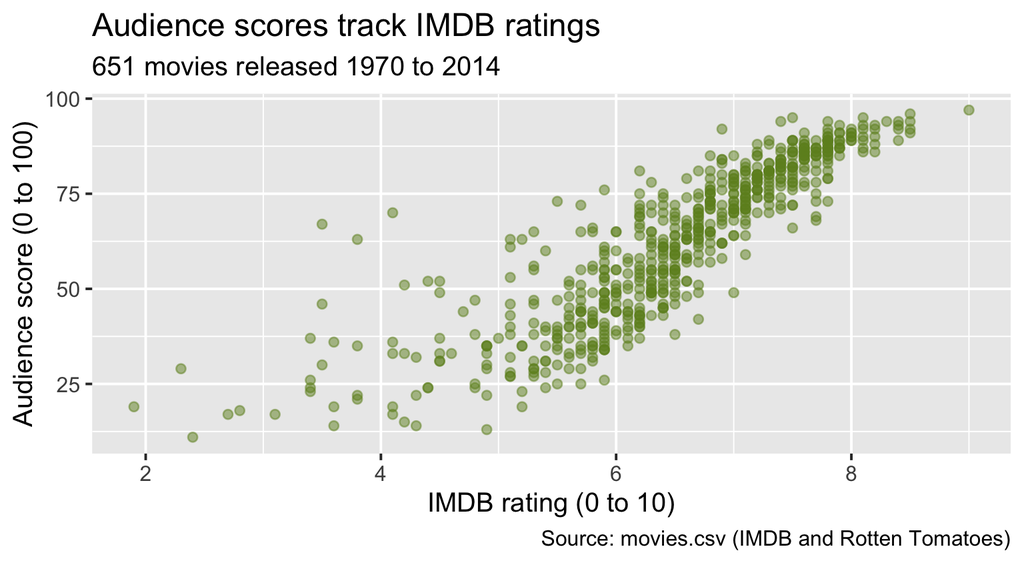

```r
p + labs(
  title = "Audience scores track IMDB ratings",
  subtitle = "651 movies released 1970 to 2014",
  x = "IMDB rating (0 to 10)", y = "Audience score (0 to 100)",
  caption = "Source: movies.csv (IMDB and Rotten Tomatoes)"
)
```

## Scales: log for skewed data

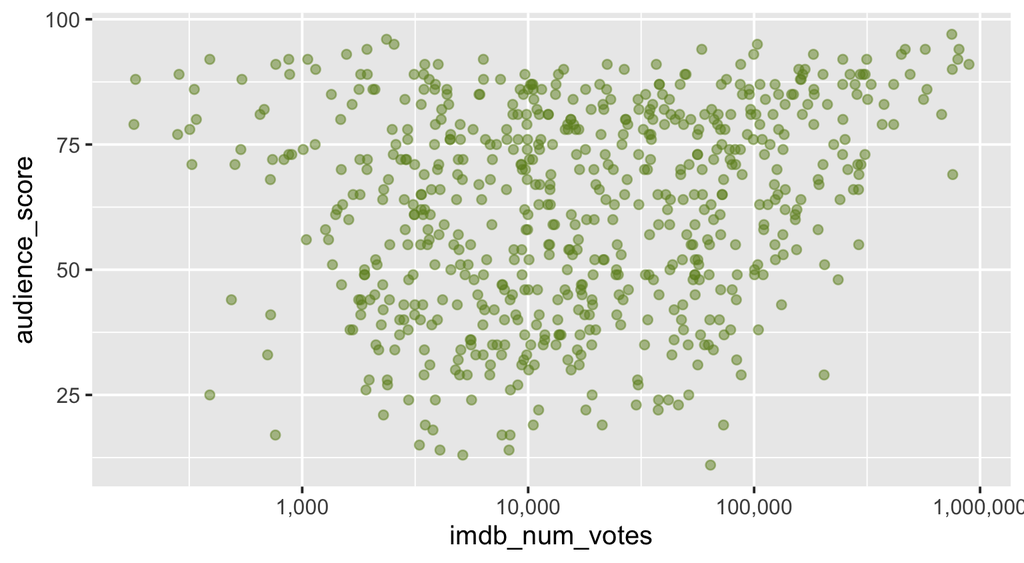

```r
ggplot(movies, aes(x = imdb_num_votes, y = audience_score)) +
  geom_point(alpha = 0.5, color = "#6d8d24") +
  scale_x_log10(labels = scales::label_comma())
```

Skewed? A log axis spreads out the crowd.

## Colors: choose on purpose

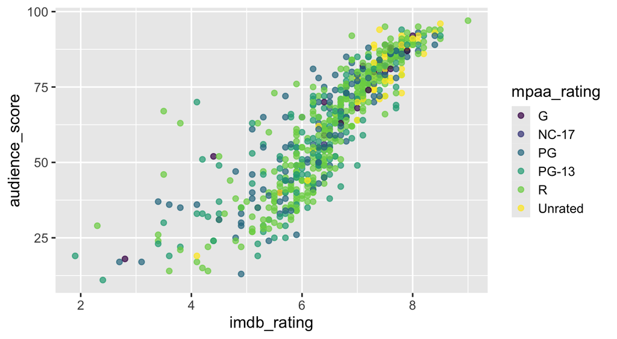

```r
ggplot(movies, aes(x = imdb_rating, y = audience_score, color = mpaa_rating)) +
  geom_point(alpha = 0.7) +
  scale_color_viridis_d()
```

`viridis` works for most color-blind viewers.

## Themes: the polish

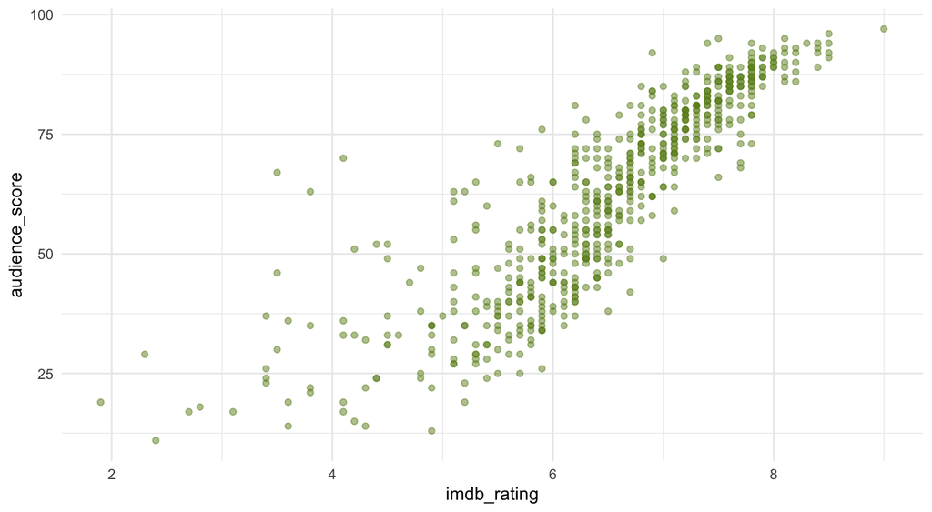

```r
p +
  theme_minimal() +
  theme(legend.position = "bottom")
```

`theme_*()` sets the look. `theme()` tweaks details.

## Save it

```r
ggsave("audience_vs_imdb.png", p, width = 8, height = 4.5, dpi = 300)
```

Set the **size** and **dpi** yourself. The default is whatever your window happened to be.

# Audit

## A plot can lie without a bug

Code that **runs** is not code that is **honest**.

An AI will happily:

- zoom the axis to make a small difference look huge
- show an average without saying how many rows are behind it
- sort categories alphabetically instead of meaningfully

## Chart audit checklist

1. **Axis**: do bars start at zero?
2. **Size**: is `n` visible for averages?
3. **Order**: is it meaningful, not alphabetical?
4. **Color**: few colors, color-blind safe?
5. **Labels**: units, a title that says something?
6. **Scale**: log or zoom? Is it stated?

## Prompting for a plot

A good plot prompt names five things:

1. **Data**: the data frame and the exact column names
2. **Message**: what the reader should see
3. **Form**: the geom, and the order of the categories
4. **Honesty rules**: zero baseline for bars, show `n`, labels with units
5. **Output**: “Return only `ggplot2` code”

## A weak prompt and a strong prompt

**Weak:** “Make a bar chart of average audience score by rating.”

**Strong:** “Using the data frame `by_rating` (columns `mpaa_rating`, `avg`, `n`), make a horizontal bar chart of `avg`, sorted from high to low. Start the axis at 0 and write `n =` at the end of each bar. Label the axis with units and give the plot a title that states the finding. Return only `ggplot2` code.”

## Task 2: prompt it

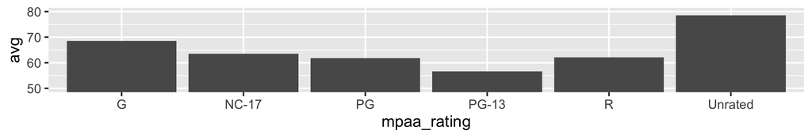

```r
ggplot(by_rating, aes(x = mpaa_rating, y = avg)) +
  geom_col() +
  coord_cartesian(ylim = c(50, 80))
```

**Prompt it (7 min).** List the problems, prompt your AI to fix them, run its code, and check it against the checklist.

## The problems

1. **Truncated axis**: bars start at 50, so the length no longer matches the value
2. **No sample size**: NC-17 has only **2** movies
3. **Arbitrary order**: alphabetical, not sorted
4. **No labels**: the axis just says `avg`

Not a coding error. A **communication** error.

## A more honest version

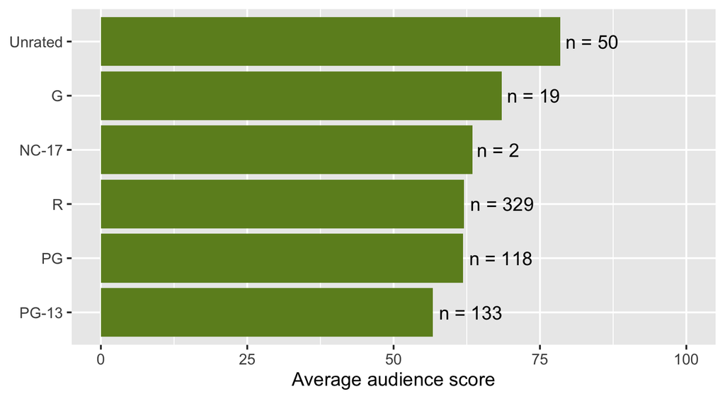

```r
ggplot(by_rating, aes(x = avg, y = fct_reorder(mpaa_rating, avg))) +
  geom_col(fill = "#6d8d24") +
  geom_text(aes(label = paste0("n = ", n)), hjust = -0.1) +
  scale_x_continuous(limits = c(0, 100)) +
  labs(x = "Average audience score", y = NULL)
```

## Bin width changes the story (FLEX)

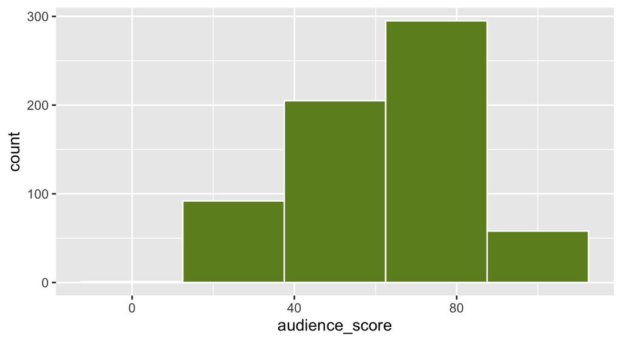

```r
ggplot(movies, aes(x = audience_score)) +
  geom_histogram(binwidth = 25, fill = "#6d8d24", color = "white")
```

Wide bins hide the shape. Always try several bin widths.

## Too many colors (FLEX)

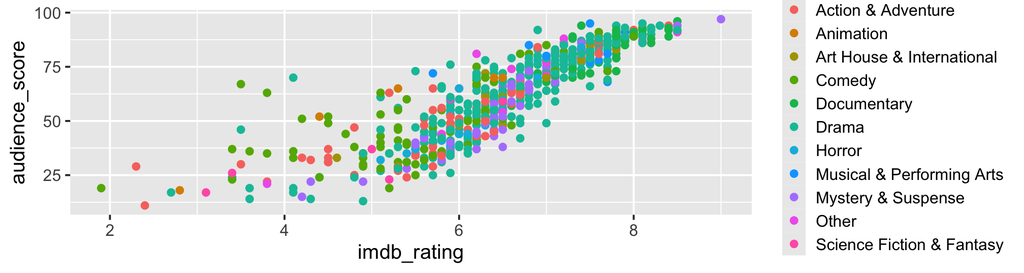

```r
ggplot(movies, aes(x = imdb_rating, y = audience_score, color = genre)) +
  geom_point()
```

Eleven colors make the reader match every dot to the legend. Use **facets**, or highlight one group and gray the rest.

## Too many colors (FLEX)

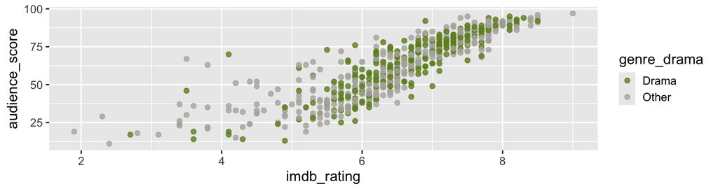

```r
movies |>
  mutate(genre_drama = ifelse(genre=="Drama","Drama","Other")) |>
  ggplot(aes(x = imdb_rating, y = audience_score, color=genre_drama)) +
  geom_point(alpha=0.8) +
  scale_color_manual(values = c("#6d8d24", "#b4b2ac"))
```

## Chart audit checklist

1. **Axis**: do bars start at zero?
2. **Size**: is `n` visible for averages?
3. **Order**: is it meaningful, not alphabetical?
4. **Color**: few colors, color-blind safe?
5. **Labels**: units, a title that says something?
6. **Scale**: log or zoom? Is it stated?

# Diagnostics and stories

## Plots find problems

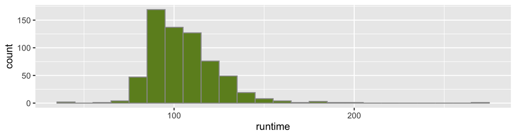

```r
ggplot(movies, aes(x = runtime)) +
  geom_histogram(binwidth = 10, fill = "#6d8d24", color = "gray60")
```

One bar far to the right: a 267-minute documentary. A plot **flags** it. You decide if it is real.

## Where is the missing data?

```r
missing_by_col <- movies |>
  summarize(across(everything(), ~ sum(is.na(.x)))) |>
  pivot_longer(everything(), names_to = "column", values_to = "n_missing") |>
  filter(n_missing > 0)
missing_by_col
```

```
#> # A tibble: 11 x 2
#>   column        n_missing
#>   <chr>             <int>
#> 1 runtime               1
#> 2 studio                8
#> 3 dvd_rel_year          8
#> 4 dvd_rel_month         8
#> 5 dvd_rel_day           8
#> # i 6 more rows
```

## Plot the missingness (FLEX)

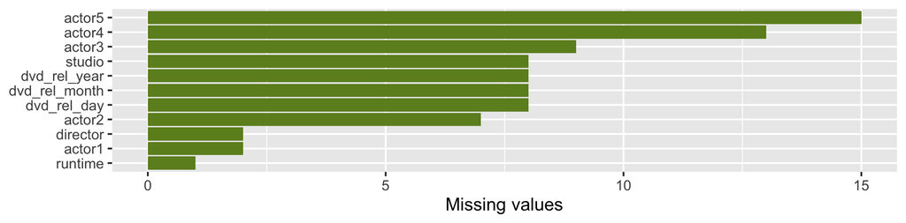

```r
ggplot(missing_by_col, aes(x = n_missing, y = fct_reorder(column, n_missing))) +
  geom_col(fill = "#6d8d24") +
  labs(x = "Missing values", y = NULL)
```

The `dvd_rel_*` columns are missing for the **same 8 films**.

## Task 3: the AI’s answer

Asked: “Show how critics and audiences rate genres differently, with a title.”

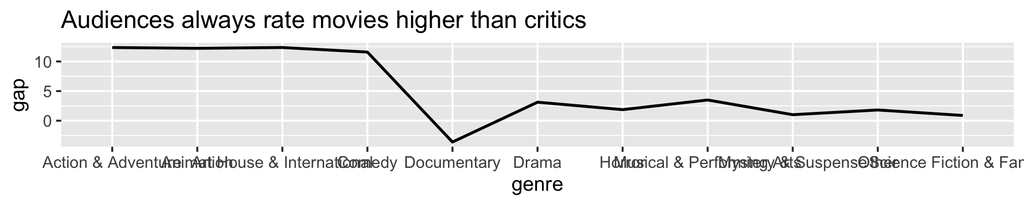

```r
gap |>
  ggplot(aes(x = genre, y = gap, group = 1)) +
  geom_line(size = 1) +
  labs(title = "Audiences always rate movies higher than critics")
```

## Task 3: assess it

**Assess it (5 min).** Run the code, then **Read**, **Run**, **Restate**.

1. What is wrong with the **code**?
2. What is wrong with the **plot**?
3. Is the **title** true?
4. Write the prompt you would send back.

## What was wrong

- **Code**: `size` for lines is deprecated (`linewidth`), and `group = 1` joins unrelated genres
- **Plot**: a line implies a trend across genres, order is alphabetical, labels collide, `gap` is not a label
- **Title**: “always” is false. Documentary goes the other way

The code ran. The **claim** was the bug.

## A better answer

```r
gap |>
  mutate(big = gap > 10) |>
  ggplot(aes(y = fct_reorder(genre, gap))) +
  geom_segment(aes(x = critics, xend = audience, yend = genre, color = big),
               linewidth = 1.5) +
  geom_point(aes(x = critics), color = "#56B4E9", size = 3) +
  geom_point(aes(x = audience), color = "#009E73", size = 3) +
  scale_color_manual(values = c("grey80", "#f68b1f"), guide = "none") +
  labs(title = "Critics score four genres about 12 points below audiences",
       subtitle = "Blue dot: critics. Green dot: audience.",
       x = "Average score", y = NULL) +
  theme_minimal(base_size = 15)
```

## The story version

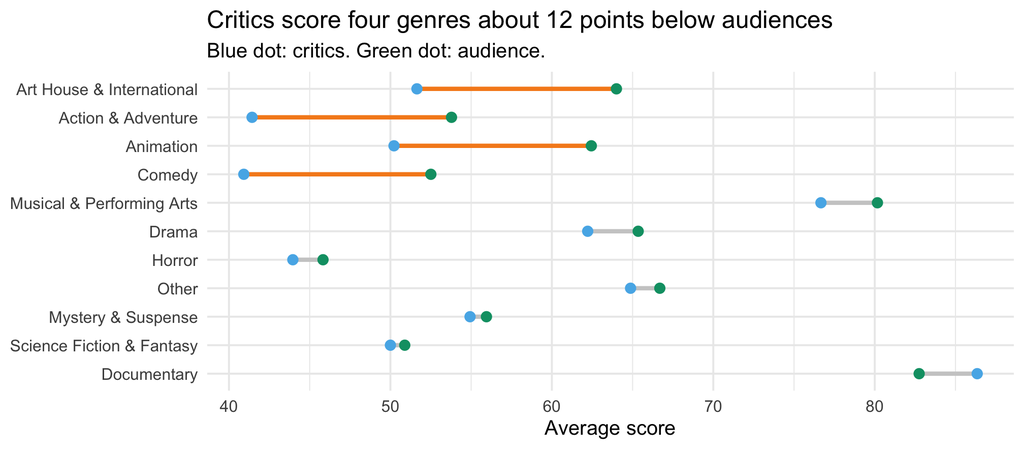

## What made it a story

1. The **title** states the finding
2. **One highlight** (orange), everything else muted
3. **Sorted** by the thing that matters
4. **Clean**: no clutter, no legend needed
5. Colors still work for **color-blind** readers

# Wrap-up

## Four things to remember

1. **Grammar**: data, aesthetics, geoms, layered with `+`. Inside `aes()` means data, outside means fixed.
2. **Choose** the geom from the question, then **audit** the plot: axis, `n`, order, color, labels.
3. A plot is a **diagnostic** and a **message**: find the problem, then state the finding.
4. **Prompt** with data, message, form, and honesty rules. **Assess** what comes back: run it and look.

## Next up

Wed 10/28: guest talk.

Mon 11/02: **Lab 2** kickoff on the WellSync data analysis. Bring a laptop.

The **handout** has the full explanations, extra practice, and the appendix material.

# Appendix

## Label points directly with ggrepel

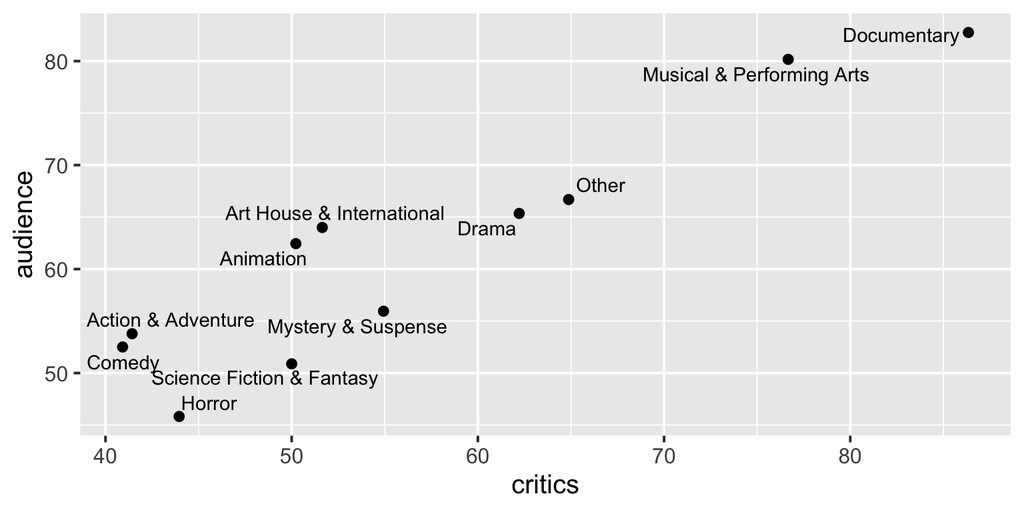

```r
# install.packages("ggrepel")  # once
library(ggrepel)

gap |>
  ggplot(aes(x = critics, y = audience, label = genre)) +
  geom_point() +
  geom_text_repel()
```

`geom_text_repel()` places labels so they do not overlap.

## Combine plots with patchwork

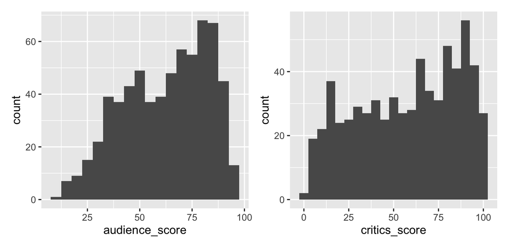

```r
# install.packages("patchwork")  # once
library(patchwork)

p1 <- ggplot(movies, aes(audience_score)) + geom_histogram(binwidth = 5)
p2 <- ggplot(movies, aes(critics_score)) + geom_histogram(binwidth = 5)

p1 + p2          # side by side
```

## Combine plots with patchwork

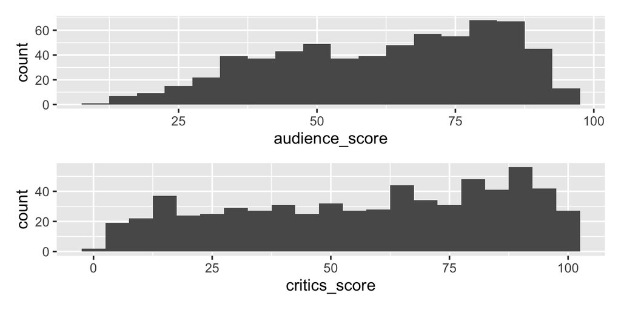

```r
# install.packages("patchwork")  # once
library(patchwork)

p1 <- ggplot(movies, aes(audience_score)) + geom_histogram(binwidth = 5)
p2 <- ggplot(movies, aes(critics_score)) + geom_histogram(binwidth = 5)

p1 / p2          # stacked
```

## Missingness plots with naniar

```r
# install.packages("naniar")  # once
library(naniar)

gg_miss_var(movies)         # bar chart of NAs per column
vis_miss(movies)            # every cell: present or missing
```

These are ready-made versions of the plot built from scratch in this session.

## Axis labels that do not fit

```r
ggplot(movies, aes(x = genre)) +
  geom_bar() +
  theme(axis.text.x = element_text(angle = 45, hjust = 1))   # tilt the labels

ggplot(movies, aes(y = genre)) +
  geom_bar()                                                  # or put the long names on y
```

Putting the category on the **y axis** is usually the easier fix.